# PracticaFinal

Noelia Fernández Pérez

2022-02-12

```r
library(markdown)
library(readxl)
library(dplyr)
library(knitr)
library(markdown)
library(ggplot2)
library(glue)
library(GGally)
library(gmodels)
library(compareGroups)
library(psych)
library(MASS)
library(lmtest)
```

```r
datosPractica <- read_excel("DatosPractica.xlsx")
```

##### Se pretende identificar ineficiencias en el proceso de venta o factores internos y externos que pueden estar impactando el rendimiento de las mismas de una empresa de dispositivos electrónicos para las franquicias de todo el país.

##### Para el desarrollo de este estudio se sugiere seguir las siguientes instrucciones:

##### 1. Análisis descriptivo. Estudiar la distribución de las variables, así como detectar posibles valores atípicos o relaciones

##### 2. Análisis del Comportamiento de las Ventas y Variables que le Afectan

##### 3. Realizar una tabla de contingencia entre Ventas y Número de empleados, una vez categorizadas ambas variables, para número de empleados, por ejemplo, la utilizada a nivel Europeo, la cual divide a las empresas en Microempresas (1-9 trabajadores), Pequeña empresa (10-49 trabajadores), Mediana empresa (50-249 trabajadores) y Gran empresa (250 y más trabajadores)).

##### 4. Comparar las ventas entre Madrid y Barcelona.

##### 5. Presentación del modelo de predicción de las ventas para el siguiente año y describirla adecuadamente.

```r
str(datosPractica)
```

```
## tibble [4,403 x 18] (S3: tbl_df/tbl/data.frame)
##  $ REGISTRO           : num [1:4403] 1 2 3 4 5 6 7 8 9 10 ...
##  $ PROVINCIA          : chr [1:4403] "Albacete" "Albacete" "Albacete" "Albacete" ...
##  $ rentabieco         : num [1:4403] 0.86 -4.748 -0.322 12.99 1.461 ...
##  $ rentabifin         : num [1:4403] 8.4 -20.15 -1.93 28.38 55.74 ...
##  $ endp               : num [1:4403] 89.8 76.4 83.3 54.2 97.4 ...
##  $ liq                : num [1:4403] 1.102 1.308 0.854 1.577 1.009 ...
##  $ PRODUCTIVIDAD      : num [1:4403] 114.9 146.4 11.7 19.3 37 ...
##  $ VENTAS             : num [1:4403] 1270 338 17715 20848 1239 ...
##  $ NÚMERO DE EMPLEADOS: num [1:4403] 1 1 46 40 2 54 1 2 8 2 ...
##  $ coe                : num [1:4403] 0.00493 0.00131 0.06871 0.08086 0.0048 ...
##  $ edad               : num [1:4403] 2 8 25 24 2 40 10 11 10 15 ...
##  $ conce              : num [1:4403] 9 9 34 34 3 34 34 34 9 34 ...
##  $ numac              : num [1:4403] 1 0 3 3 0 1 1 1 3 0 ...
##  $ numpa              : num [1:4403] 0 0 0 0 0 0 0 0 0 0 ...
##  $ numest             : num [1:4403] 1 1 2 2 2 7 1 1 1 2 ...
##  $ estp               : num [1:4403] 0 0 0 0 0 1 0 0 0 0 ...
##  $ grupo              : num [1:4403] 0 0 0 0 0 0 0 0 0 0 ...
##  $ fju                : num [1:4403] 0 0 1 1 0 1 0 0 1 1 ...
```

**El fichero nos vuelca 4403 registros distribuidos en 18 categorías.**

**Observando los datos, considero que es necesario recodificar alguna variable; para ello creo un nuevo** **dataframe con el nombre “practica”, aunque antes hago las siguientes modificaciones:**

- Simplifico la variable Provincias en 6 grupos, atendiendo al tamaño de su población, de la siguiente manera:

  ```
      GRUPO 1 ( Hasta  99.999h )

      GRUPO 2 ( 100.000h - 299.999h)

      GRUPO 3 ( 300.000h - 599.999h)

      GRUPO 4 ( 600.000h - 1.499.999h)

      GRUPO 5 ( 1.500.000 - 2999.999 )- Barcelona

      GRUPO 6 ( +  3.000.000h) - Madrid
  ```

- Variable REGISTRO: no aporta valor al estudio, no la tengo en cuenta.
- Variable estp: añadír SI, si tiene centros en otra provincia y NO, si no los tiene.
- Variable grupo: no tengo información, por lo tanto prescindo de ella.
- Variable fju: no tengo información, porlo tanto prescindo de ella.
- Renombro las columnas PRODUCTIVIDAD y NÚMERO DE EMPLEADOS

```r
datosProvincias <- read_excel("DatosProvincias.xlsx")
```

```r
datos_join <- datosPractica |>
  left_join(datosProvincias, by = "PROVINCIA") |>
  dplyr::select(-PROVINCIA)
```

```r
datos_org <- datos_join |>
  mutate(
    estp = factor(estp, levels = 0:1, labels = c("No", "Si")),
    GRUPOS_PROVINCIAS = factor(GRUPOS_PROVINCIAS)
  ) |>
  dplyr::select( -c(REGISTRO, grupo, fju))
datos_org
```

```
## # A tibble: 4,403 x 15
##    rentabieco rentabifin  endp   liq PRODUCTIVIDAD VENTAS `NÚMERO DE EMPLEADOS`
##         <dbl>      <dbl> <dbl> <dbl>         <dbl>  <dbl>                 <dbl>
##  1      0.860       8.40  89.8 1.10         115.    1270.                     1
##  2     -4.75      -20.1   76.4 1.31         146.     338.                     1
##  3     -0.322      -1.93  83.3 0.854         11.7  17715.                    46
##  4     13.0        28.4   54.2 1.58          19.3  20848.                    40
##  5      1.46       55.7   97.4 1.01          37.0   1239.                     2
##  6      1.59        6.80  76.5 1.26          13.1  20071.                    54
##  7      9.97       31.7   68.5 0.588         12.0    273.                     1
##  8      4.38       11.3   61.3 0.943         70.8   1926.                     2
##  9      1.75       10.2   82.9 1.06           4.94   382.                     8
## 10      0.225      -1.57 114.  1.26           2.50   250.                     2
## # ... with 4,393 more rows, and 8 more variables: coe <dbl>, edad <dbl>,
## #   conce <dbl>, numac <dbl>, numpa <dbl>, numest <dbl>, estp <fct>,
## #   GRUPOS_PROVINCIAS <fct>
```

```r
practica <-
  rename(datos_org, Pdtvidad = PRODUCTIVIDAD, NºEmp = `NÚMERO DE EMPLEADOS`)
practica
```

```
## # A tibble: 4,403 x 15
##    rentabieco rentabifin  endp   liq Pdtvidad VENTAS NºEmp      coe  edad conce
##         <dbl>      <dbl> <dbl> <dbl>    <dbl>  <dbl> <dbl>    <dbl> <dbl> <dbl>
##  1      0.860       8.40  89.8 1.10    115.    1270.     1 0.00493      2     9
##  2     -4.75      -20.1   76.4 1.31    146.     338.     1 0.00131      8     9
##  3     -0.322      -1.93  83.3 0.854    11.7  17715.    46 0.0687      25    34
##  4     13.0        28.4   54.2 1.58     19.3  20848.    40 0.0809      24    34
##  5      1.46       55.7   97.4 1.01     37.0   1239.     2 0.00480      2     3
##  6      1.59        6.80  76.5 1.26     13.1  20071.    54 0.0779      40    34
##  7      9.97       31.7   68.5 0.588    12.0    273.     1 0.00106     10    34
##  8      4.38       11.3   61.3 0.943    70.8   1926.     2 0.00747     11    34
##  9      1.75       10.2   82.9 1.06      4.94   382.     8 0.00148     10     9
## 10      0.225      -1.57 114.  1.26      2.50   250.     2 0.000970    15    34
## # ... with 4,393 more rows, and 5 more variables: numac <dbl>, numpa <dbl>,
## #   numest <dbl>, estp <fct>, GRUPOS_PROVINCIAS <fct>
```

```r
summary(datos_org)
```

```
##    rentabieco          rentabifin            endp             liq
##  Min.   :-179.7045   Min.   :-459.480   Min.   :  0.00   Min.   :  0.01527
##  1st Qu.:   0.1294   1st Qu.:   2.658   1st Qu.: 61.21   1st Qu.:  0.94691
##  Median :   1.7748   Median :  10.671   Median : 79.15   Median :  1.15317
##  Mean   :   0.7648   Mean   :  16.198   Mean   : 79.53   Mean   :  1.90566
##  3rd Qu.:   4.8275   3rd Qu.:  24.988   3rd Qu.: 93.25   3rd Qu.:  1.54464
##  Max.   :  48.4145   Max.   : 494.178   Max.   :433.21   Max.   :113.15031
##  PRODUCTIVIDAD         VENTAS         NÚMERO DE EMPLEADOS      coe
##  Min.   : -1.172   Min.   :    4.92   Min.   :  1.00      Min.   :0.0000012
##  1st Qu.:  5.085   1st Qu.:  494.89   1st Qu.:  3.00      1st Qu.:0.0004909
##  Median : 11.755   Median : 1592.14   Median :  7.00      Median :0.0021491
##  Mean   : 16.224   Mean   : 6648.16   Mean   : 16.34      Mean   :0.0118101
##  3rd Qu.: 18.783   3rd Qu.: 7819.91   3rd Qu.: 21.00      3rd Qu.:0.0106936
##  Max.   :268.593   Max.   :77055.79   Max.   :169.00      Max.   :0.5060498
##       edad           conce           numac            numpa
##  Min.   : 0.00   Min.   :  1.0   Min.   : 0.000   Min.   : 0.0000
##  1st Qu.: 5.00   1st Qu.:  4.0   1st Qu.: 0.000   1st Qu.: 0.0000
##  Median :11.00   Median : 11.0   Median : 1.000   Median : 0.0000
##  Mean   :12.29   Mean   : 29.8   Mean   : 1.228   Mean   : 0.1687
##  3rd Qu.:18.00   3rd Qu.: 28.0   3rd Qu.: 2.000   3rd Qu.: 0.0000
##  Max.   :49.00   Max.   :215.0   Max.   :17.000   Max.   :20.0000
##      numest       estp               GRUPOS_PROVINCIAS
##  Min.   : 1.000   No:4264   GRUPO-1-          : 732
##  1st Qu.: 1.000   Si: 139   GRUPO-2-          :1018
##  Median : 1.000             GRUPO-3-          : 705
##  Mean   : 1.714             GRUPO-4-          : 929
##  3rd Qu.: 2.000             GRUPO-5- Barcelona: 546
##  Max.   :34.000             GRUPO-6- Madrid   : 473
```

##### **1. Análisis descriptivo. Estudiar la distribución de las variables, así como detectar posibles valores atípicos o relaciones.**

A través de ggpairs podemos calcular las correlaciones entre las variables y, al mismo tiempo, producir todos los gráficos entre las variables y gráficos de distribución de densidad de cada variable, permite descubrir la colinealidad entre covariables.

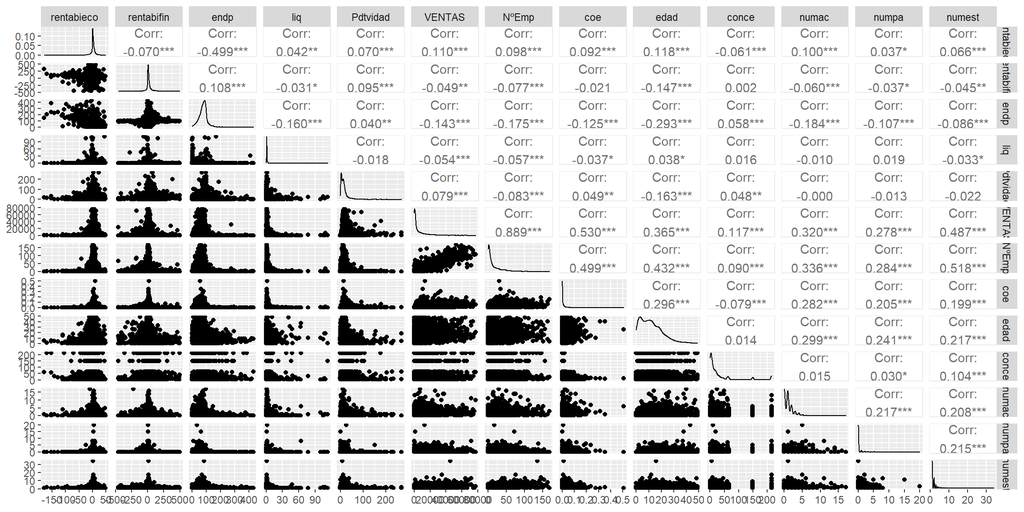

```r
ggpairs (practica, 1:13)
```

Del mismo modo, comprobamos en conjunto la normalidad de las variables numéricas, aplicando el Shapiro-test.

```r
normalidad <-
sapply ((dplyr::select ( practica, -GRUPOS_PROVINCIAS, - estp )), shapiro.test)
normalidad
```

```
##           rentabieco                    rentabifin
## statistic 0.6228056                     0.6703634
## p.value   2.798948e-71                  1.423589e-68
## method    "Shapiro-Wilk normality test" "Shapiro-Wilk normality test"
## data.name "X[[i]]"                      "X[[i]]"
##           endp                          liq
## statistic 0.8169595                     0.170466
## p.value   2.179416e-57                  3.508273e-88
## method    "Shapiro-Wilk normality test" "Shapiro-Wilk normality test"
## data.name "X[[i]]"                      "X[[i]]"
##           Pdtvidad                      VENTAS
## statistic 0.5893254                     0.6209728
## p.value   5.147669e-73                  2.231799e-71
## method    "Shapiro-Wilk normality test" "Shapiro-Wilk normality test"
## data.name "X[[i]]"                      "X[[i]]"
##           NºEmp                         coe
## statistic 0.6842273                     0.4773535
## p.value   1.011508e-67                  4.733963e-78
## method    "Shapiro-Wilk normality test" "Shapiro-Wilk normality test"
## data.name "X[[i]]"                      "X[[i]]"
##           edad                          conce
## statistic 0.9273678                     0.5573085
## p.value   7.027458e-42                  1.451701e-74
## method    "Shapiro-Wilk normality test" "Shapiro-Wilk normality test"
## data.name "X[[i]]"                      "X[[i]]"
##           numac                         numpa
## statistic 0.7215549                     0.2374069
## p.value   2.929726e-65                  2.736419e-86
## method    "Shapiro-Wilk normality test" "Shapiro-Wilk normality test"
## data.name "X[[i]]"                      "X[[i]]"
##           numest
## statistic 0.5437766
## p.value   3.432687e-75
## method    "Shapiro-Wilk normality test"
## data.name "X[[i]]"
```

Comprobamos que en todas ellas el p-valor es < 0.05, por lo que no siguen una distribución normal, con un nivel de confianza del 95%.

Lo siguiente que haremos será analizar individualmente las variables, para discernir las posibles relaciones entre ellas.

*1.- Variable Rentabieco* Hace referencia a la Rentabilidad Económica de cada franquicia, conocida como ROA; se trata de la relación entre el beneficio bruto (antes de impuestos) y el activo total. Cuanto mayor sea este ratio, mejor, porque indicará que se requieren pocos activos para lograr un beneficio alto.

```r
summary(practica$rentabieco)
```

```
##      Min.   1st Qu.    Median      Mean   3rd Qu.      Max.
## -179.7045    0.1294    1.7748    0.7648    4.8275   48.4145
```

En este caso observamos como al ser la Media < Mediana la ROA presenta una distribución asimétrica negativa.

Cuando el ROE es inferior al ROA, esto indica que el coste medio de la deuda es superior a la rentabilidad económica.

```r
psych::describe(practica$rentabieco)
```

```
##    vars    n mean   sd median trimmed  mad    min   max  range  skew kurtosis
## X1    1 4403 0.76 13.4   1.77    2.08 3.52 -179.7 48.41 228.12 -4.43    38.89
##     se
## X1 0.2
```

La curtosis tiene un valor de 38.89. Es mucho mayor que cero, por lo que la distribución es leptocúrtica, con alta concentración de valores entorno a la media.

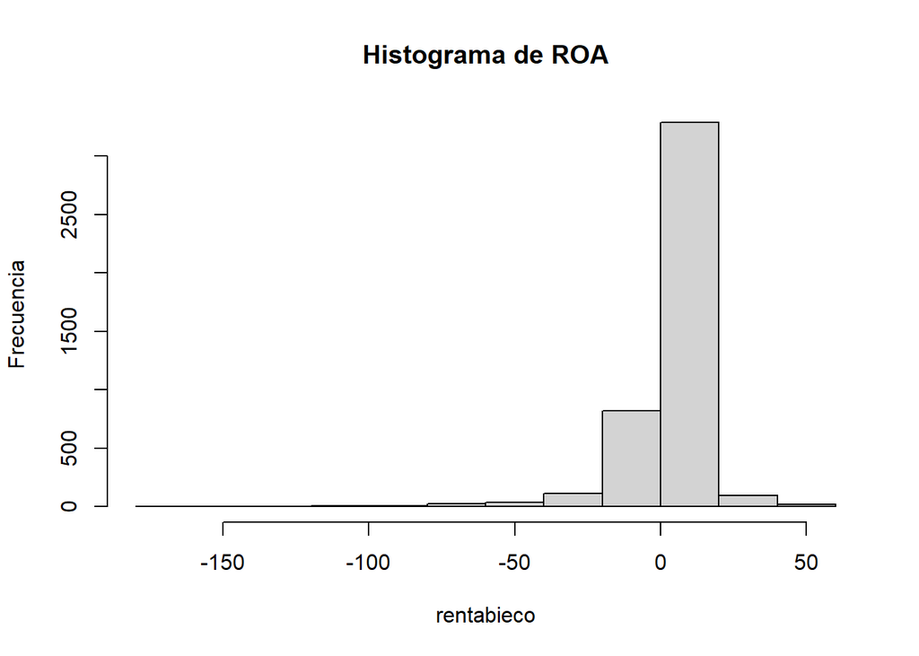

```r
hist(x = practica$rentabieco, main = "Histograma de ROA", xlab = "rentabieco", ylab = "Frecuencia")
```

El 50% de las franquicias están dentro de un intervalo entre el 0.12 y el 4,82 de rentabilidad. Visualmente confirmamos que estamos ante una distribución con asimetría negativa. Este indicador ayuda a conocer si tu empresa es rentable en relación con los activos totales. Para poder afirmar esta rentabilidad el ROA debe ser mayor de 5%.

*2.- Variable Rentabifin* Se refiere a la Rentabilidad financiera, conocida como ROE, y mide la relación entre el beneficio neto y los fondos propios.

```r
summary(practica$rentabifin)
```

```
##     Min.  1st Qu.   Median     Mean  3rd Qu.     Max.
## -459.480    2.658   10.671   16.198   24.988  494.178
```

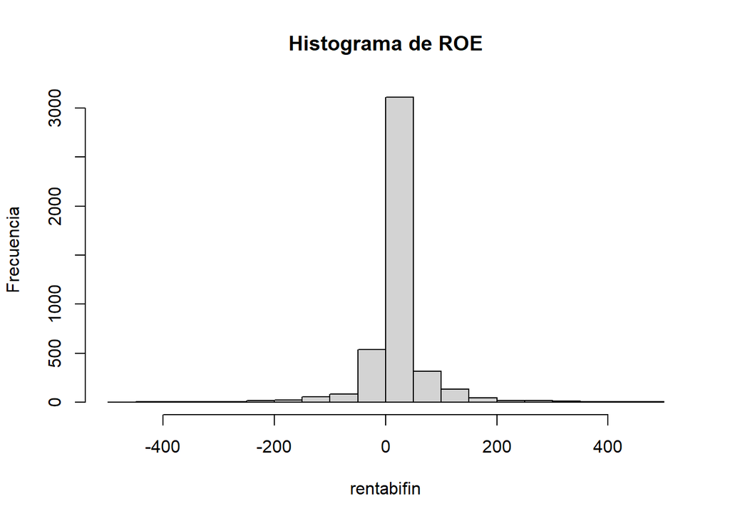

```r
hist(practica$rentabifin, main = "Histograma de ROE", xlab = "rentabifin", ylab = "Frecuencia")
```

Comprobamos nuevamente que dichos valores no siguen una distribución normal.

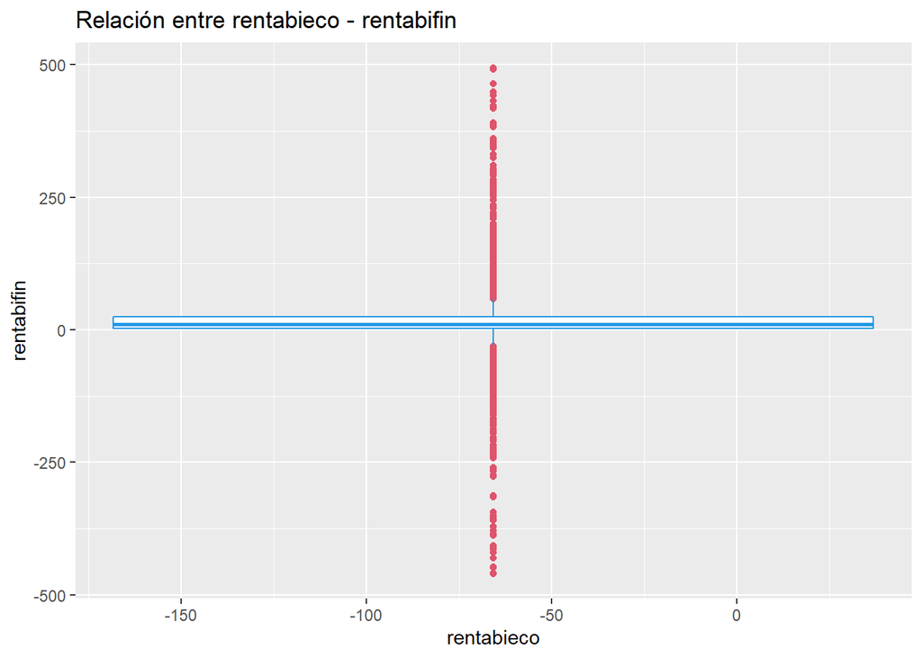

```r
practica |>
  ggplot(aes(x = rentabieco, y = rentabifin))+
    geom_boxplot(color = 12,
                 outlier.colour = 2)+
  ggtitle ("Relación entre rentabieco - rentabifin")
```

Vamos a ver la correlación entre estas dos primeras variables, utilizando la correlación de Spearman, puesto que no siguen una distribución normal.

```r
cor.test(practica$rentabieco, practica$rentabifin, method = "spearman")
```

```
##
##  Spearman's rank correlation rho
##
## data:  practica$rentabieco and practica$rentabifin
## S = 9095913720, p-value < 2.2e-16
## alternative hypothesis: true rho is not equal to 0
## sample estimates:
##      rho
## 0.360631
```

En el ggpairs del inicio el resultado de la correlación entre ambas variables era calculado por el método Pearson.

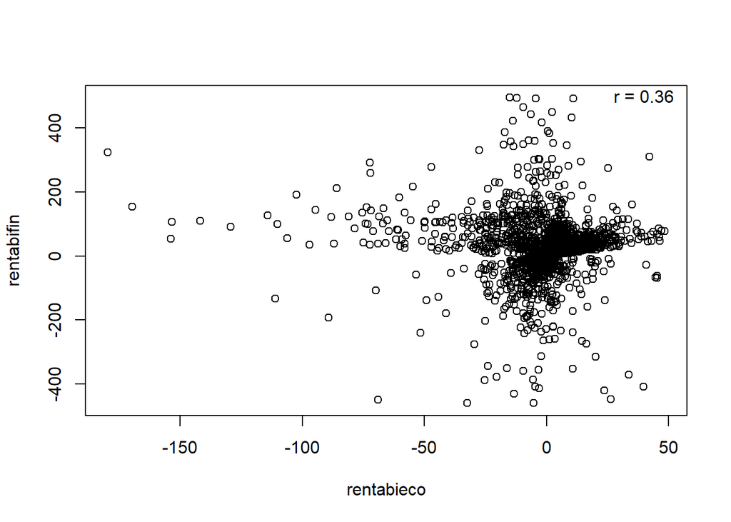

```r
cor_coef = cor(practica$rentabieco, practica$rentabifin, method = "spearman")
plot(practica$rentabieco, practica$rentabifin, xlab = "rentabieco", ylab = "rentabifin")
text(40, 500, glue::glue ("r = {round (cor_coef, 2)}"))
```

ROA y ROE están muy relacionadas, una contiene a la otra, por lo que ya vimos en sus propias definiciones. Por eso podremos no tener en cuenta a una de ellas, y evitar así que distorsiene la predicción. El ROE no tiene en cuenta el ratio de endeudamiento, por ello el ROA nos aporta más valor, y será con el que valoraremos quedarnos.

*3.- Variable End* Mide el endeudamiento de las franquicias. Se trata de un ratio entre el Pasivo de la empresa y su Patrimonio Neto.A través de él se puede saber qué tan dependiente está la empresa de la financiación ajena.

```r
summary(practica$endp)
```

```
##    Min. 1st Qu.  Median    Mean 3rd Qu.    Max.
##    0.00   61.21   79.15   79.53   93.25  433.21
```

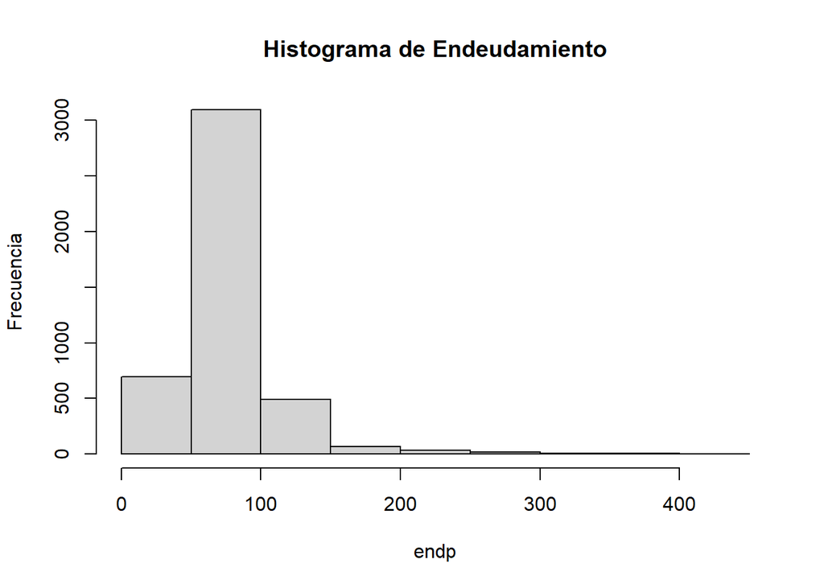

```r
hist(practica$endp, main = "Histograma de Endeudamiento", xlab = "endp", ylab = "Frecuencia")
```

*4.- Variable Liq* Hace referencia a la liquidez de las franquicias. La liquidez es una medida fundamental consecuencia de la rentabilidad y la salud financiera de una empresa; es un indicador clave para valorar si las franquicias generan valor, ya sea por el alto valor añadido de su producto o servicio, o por su eficiencia productiva. Es de las mejores medidas para saber si las cosas se están haciendo bien o, por el contrario, es necesario mejorarlas.

```r
summary(practica$liq)
```

```
##      Min.   1st Qu.    Median      Mean   3rd Qu.      Max.
##   0.01527   0.94691   1.15317   1.90566   1.54464 113.15031
```

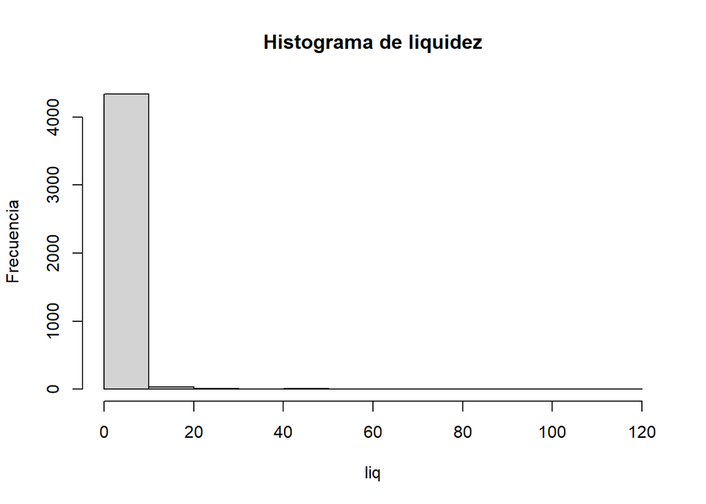

```r
hist(practica$liq, main = "Histograma de liquidez", xlab = "liq", ylab = "Frecuencia")
```

La liquidez presenta una clara asimetría positiva. Vemos como está concentrada entre el 0.94 y 1.54 para más del 50% de las franquicias, pero encontramos algunas tiendas cuya liquidez se dispara hasta valores como 113.15, pudiendo considerarse outliers.

Podemos afirmar que el grado de liquidez está muy concentrado alrededor del 1, y la asimetría es positiva.

Como ya indicamos, la liquidez está relacionada por definición con el endeudamiento.

Aplicamos Spearman, por no seguir una distribución normal:

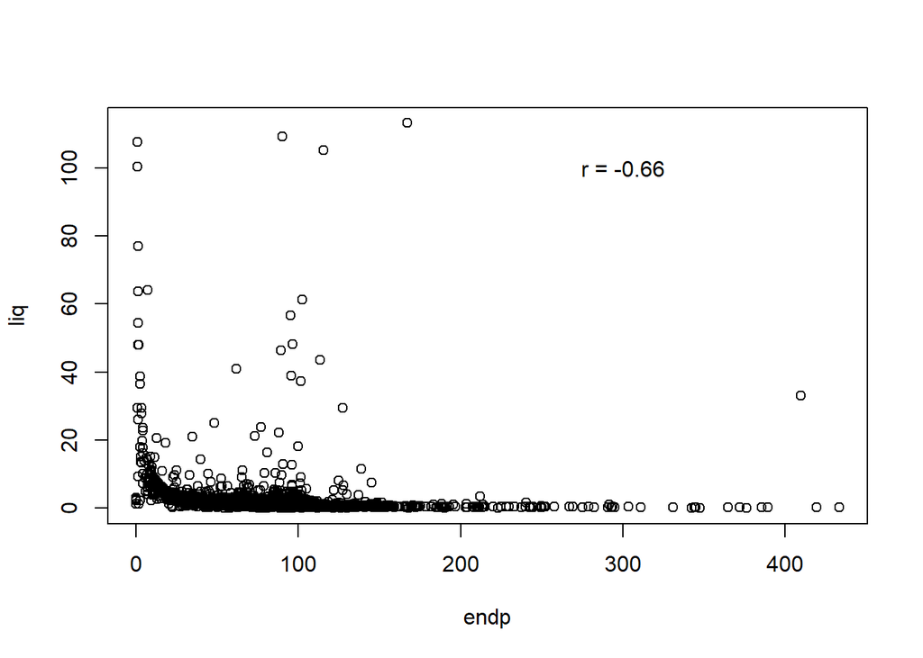

```r
cor_coef2 = cor(practica$endp, practica$liq, method = "spearman")
plot(practica$endp, practica$liq, xlab = "endp", ylab = "liq")
text(300, 100, glue::glue ("r = {round (cor_coef2, 2)}"))
```

Hay una correlación negativa significativa entre la liquidez de las franquicias y su nivel de endeudamiento; de cara a crear el modelo de regresión quizá habría que prescindir de una de ellas, ya que podría afectar al nivel de independencia.

*5.- Variable Productividad (Pdtvidad)* Es un indicador de eficiencia que pone en relación los recursos que se invierten y los resultados obtenidos; Requiere del estudio y análisis de todos los elementos que conforman las franquicias, para saber en qué medida contribuyen a la consecución de los objetivos marcados y cómo podemos optimizarlos para conseguir un mayor rendimiento de ellos. como ratio, la productividad nos permite saber si la empresa está consiguiendo la rentabilidad adecuada.

```r
summary(practica$Pdtvidad)
```

```
##    Min. 1st Qu.  Median    Mean 3rd Qu.    Max.
##  -1.172   5.085  11.755  16.224  18.783 268.593
```

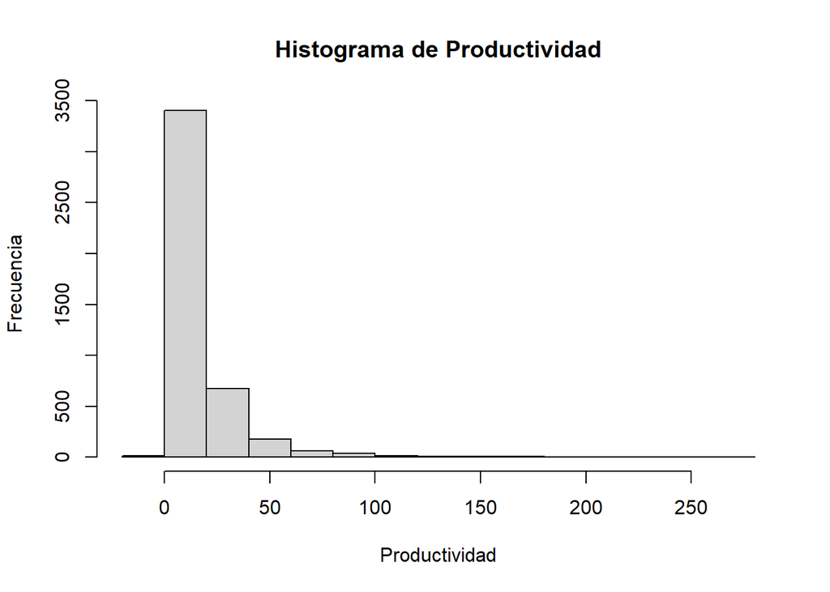

```r
hist(practica$Pdtvidad, main = "Histograma de Productividad", xlab = "Productividad", ylab = "Frecuencia")
```

```r
corr <-
dplyr::select(practica, -estp, -GRUPOS_PROVINCIAS)
```

*Correlaciones más significativas de las variables numéricas*

```r
correlacion_indep <-round (cor(corr, method = "spearman"), 2)
correlacion_indep
```

```
##            rentabieco rentabifin  endp   liq Pdtvidad VENTAS NºEmp   coe  edad
## rentabieco       1.00       0.36 -0.50  0.37     0.16   0.24  0.17  0.22  0.14
## rentabifin       0.36       1.00  0.17 -0.08     0.16  -0.05 -0.14 -0.04 -0.26
## endp            -0.50       0.17  1.00 -0.66     0.04  -0.28 -0.33 -0.27 -0.42
## liq              0.37      -0.08 -0.66  1.00     0.02   0.14  0.12  0.11  0.22
## Pdtvidad         0.16       0.16  0.04  0.02     1.00   0.49  0.00  0.42 -0.10
## VENTAS           0.24      -0.05 -0.28  0.14     0.49   1.00  0.81  0.84  0.41
## NºEmp            0.17      -0.14 -0.33  0.12     0.00   0.81  1.00  0.70  0.53
## coe              0.22      -0.04 -0.27  0.11     0.42   0.84  0.70  1.00  0.37
## edad             0.14      -0.26 -0.42  0.22    -0.10   0.41  0.53  0.37  1.00
## conce           -0.03      -0.04 -0.02  0.00     0.19   0.26  0.16  0.12  0.05
## numac            0.16      -0.06 -0.25  0.12     0.18   0.54  0.49  0.48  0.33
## numpa            0.06      -0.07 -0.16  0.05     0.05   0.33  0.34  0.28  0.26
## numest           0.09      -0.03 -0.11  0.02     0.11   0.43  0.43  0.35  0.23
##            conce numac numpa numest
## rentabieco -0.03  0.16  0.06   0.09
## rentabifin -0.04 -0.06 -0.07  -0.03
## endp       -0.02 -0.25 -0.16  -0.11
## liq         0.00  0.12  0.05   0.02
## Pdtvidad    0.19  0.18  0.05   0.11
## VENTAS      0.26  0.54  0.33   0.43
## NºEmp       0.16  0.49  0.34   0.43
## coe         0.12  0.48  0.28   0.35
## edad        0.05  0.33  0.26   0.23
## conce       1.00  0.14  0.10   0.11
## numac       0.14  1.00  0.26   0.27
## numpa       0.10  0.26  1.00   0.22
## numest      0.11  0.27  0.22   1.00
```

La productividad presenta la mayor correlación positiva con las Ventas (0.49). A mayores, existe correlación positiva significativa entre productividad y cuota de mercado (coe) de las franquicias (0.42).

*6.- Variable Nº Empleados* Hace referencia al número de empleados en cada franquicia.

```r
summary(practica$NºEmp)
```

```
##    Min. 1st Qu.  Median    Mean 3rd Qu.    Max.
##    1.00    3.00    7.00   16.34   21.00  169.00
```

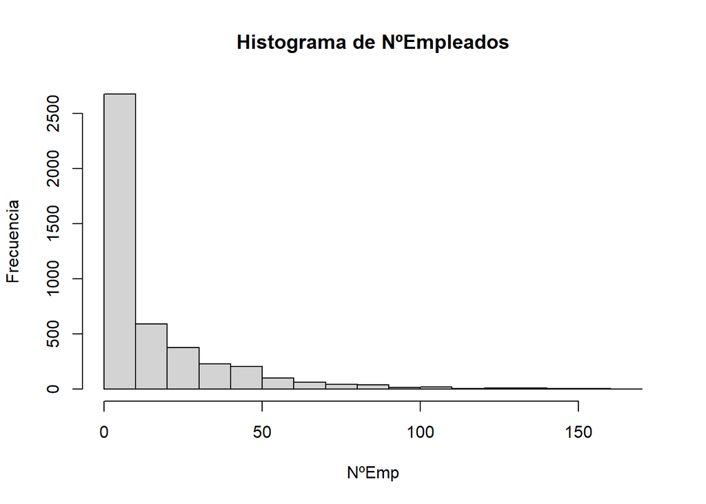

```r
hist(practica$NºEmp, main = "Histograma de NºEmpleados", xlab = "NºEmp", ylab = "Frecuencia")
```

*7.- Variable Coe* Hace referencia a la cuota de mercado; a la proporción del mercado que consume los productos y/o servicios de las franquicias. Esta variable tiene en cuenta el dato de las Ventas para cada observación / Grupo de provincia a la que pertenece.

Los datos sobre la cuota de mercado indican el tamaño del mercado y la proporción de cada tienda respecto a la competencia.

```r
summary(practica$coe)
```

```
##      Min.   1st Qu.    Median      Mean   3rd Qu.      Max.
## 0.0000012 0.0004909 0.0021491 0.0118101 0.0106936 0.5060498
```

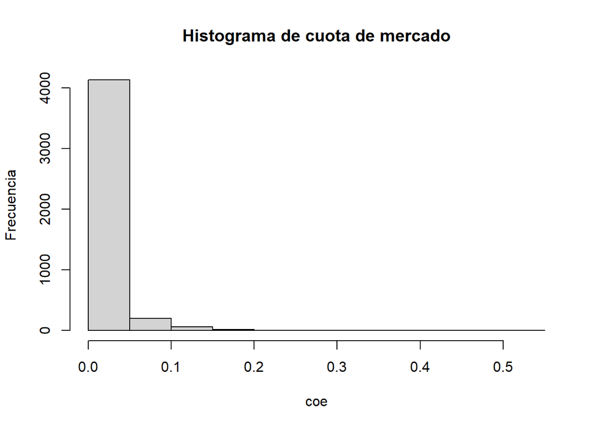

```r
hist(practica$coe, main = "Histograma de cuota de mercado", xlab = "coe", ylab = "Frecuencia")
```

La mayoría de las franquicias concentran su coe entre el 0 y el 0.1. Sigue una distribución asimétrica positiva.

*8.- Variable edad* Tiempo que ha transcurrido desde que se inauguró cada franquicia.

```r
psych::describe(practica$edad)
```

```
##    vars    n  mean   sd median trimmed mad min max range skew kurtosis   se
## X1    1 4403 12.29 9.16     11   11.28 8.9   0  49    49 1.01     1.05 0.14
```

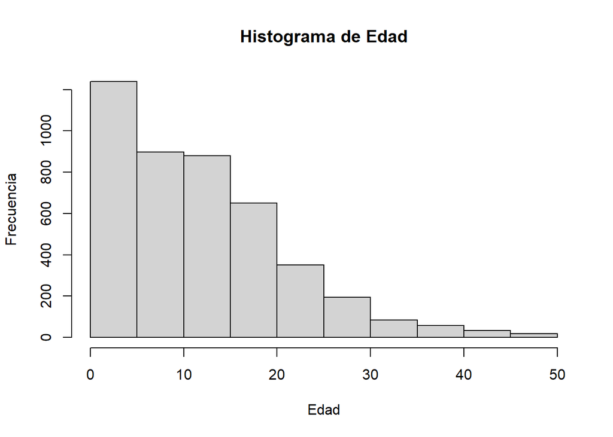

```r
hist(practica$edad, main = "Histograma de Edad", xlab = "Edad", ylab = "Frecuencia")
```

Se entiende que existen más empresas de nueva creación que de antiguedad superior a 20 años. La media se situa entre 12 años, y el 50 % de las franquicias tienen una antiguedad de entre 5 y 18 años. Presenta asimetría positiva, y curtosis baja (1.05), con respecto a las varibales estudiadas por el momento.

*9.- Variable Conce* Se trata de la competencia que cada franquicia tiene en su zona.

```r
summary(practica$conce)
```

```
##    Min. 1st Qu.  Median    Mean 3rd Qu.    Max.
##     1.0     4.0    11.0    29.8    28.0   215.0
```

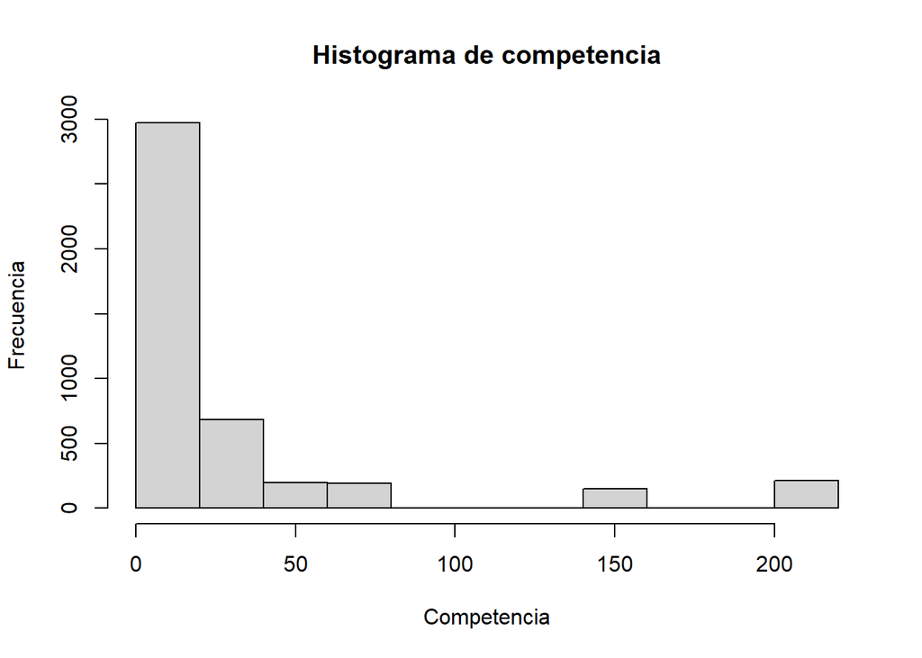

```r
hist(x= practica$conce, main = "Histograma de competencia", xlab = "Competencia", ylab = "Frecuencia")
```

El 50 % tienen entre 4 y 28 entidades que dan el mismo servicio en sus respectivos municipios. Si bien hay valores que se disparan del valor medio, como el valor máximo de 215, a prioi no pueden considerarse valores atípicos, porque corresponden a poblaciones como Madrid y Barcelona, con mayor número de población que las provincias con valores más bajos.

*10.- Variable Numac* nº de accionistas por franquicia.

```r
summary(practica$numac)
```

```
##    Min. 1st Qu.  Median    Mean 3rd Qu.    Max.
##   0.000   0.000   1.000   1.228   2.000  17.000
```

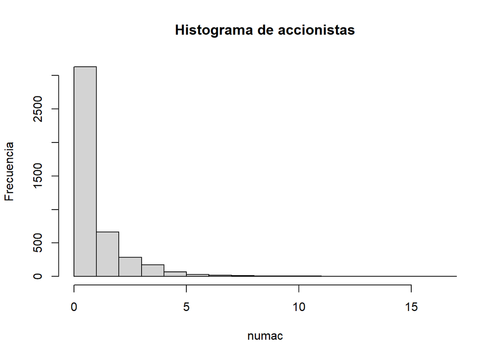

```r
hist(x = practica$numac, main = "Histograma de accionistas", xlab = "numac", ylab = "Frecuencia")
```

*11.- Variable Numpa* nº de participados por franquicia.

```r
summary(practica$numpa)
```

```
##    Min. 1st Qu.  Median    Mean 3rd Qu.    Max.
##  0.0000  0.0000  0.0000  0.1687  0.0000 20.0000
```

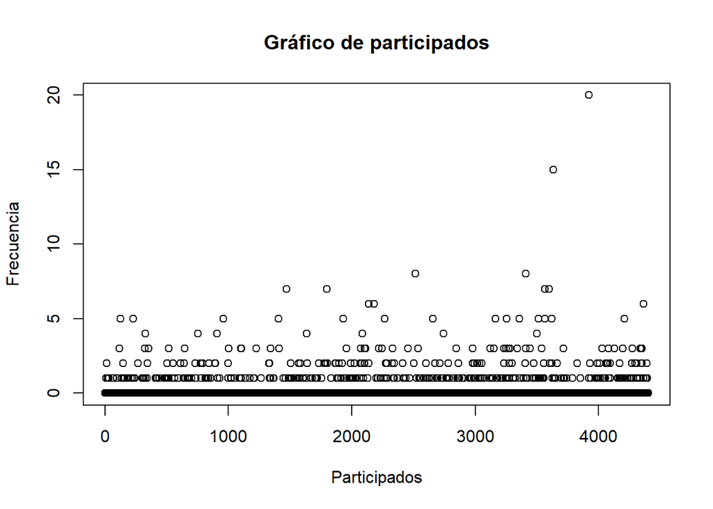

```r
plot(x= practica$numpa, main = "Gráfico de participados", xlab = "Participados", ylab = "Frecuencia")
```

El 75% de las franquicias no presentan ningún participado. La media es muy baja, próxima al 0. Con el gráfico se aprecia mejor que existen valores que se disparan, outliers, 20 y 15, y que pueden estar distorsionando la muestra.

*12.- Variable Numest* Hace referencia al número de establecimientos por empresa.

```r
summary(practica$numest)
```

```
##    Min. 1st Qu.  Median    Mean 3rd Qu.    Max.
##   1.000   1.000   1.000   1.714   2.000  34.000
```

En este caso el 50% de los valores se concentran en un número entre el 1 y 2, siendo la media inferior a 2.

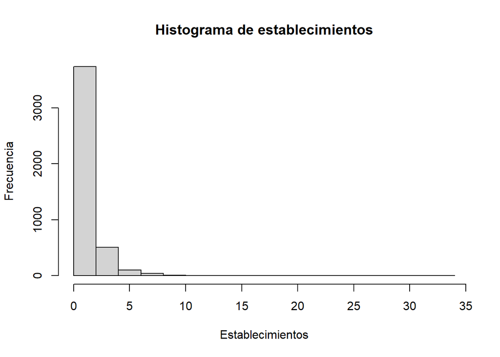

```r
hist(x= practica$numest, main = "Histograma de establecimientos", xlab = "Establecimientos", ylab = "Frecuencia" )
```

*13.- Variable Estp* Número de establecimientos en otras provincias.

```r
summary(practica$estp)
```

```
##   No   Si
## 4264  139
```

La mayor parte no tienen establecimientos en otras provincias.

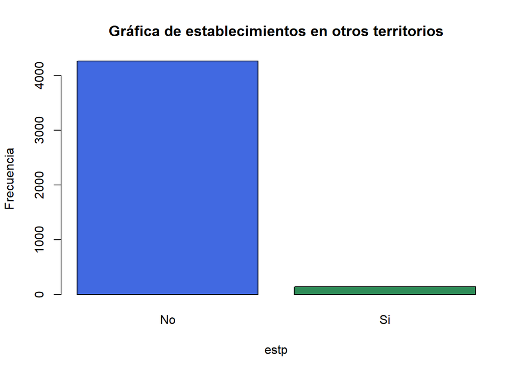

```r
plot(practica$estp, main = "Gráfica de establecimientos en otros territorios",
     xlab = "estp", ylab = "Frecuencia",
     col = c("royalblue", "seagreen"))
```

*14.- Variable Ventas* Mide el total de las ventas para cada franquicia, entiendo que se trata de un valor anualizado.

```r
summary(practica$VENTAS)
```

```
##     Min.  1st Qu.   Median     Mean  3rd Qu.     Max.
##     4.92   494.89  1592.14  6648.16  7819.91 77055.79
```

En este caso podemos ver como la media es varias veces superior a la mediana. Esto indica presencia de valores atípicos altos.

La mediana es inferior a la media por lo que la distribución de la variable VENTAS para la totalidad de las provincias presenta una asimetría positiva. Los valores no se ajustan a una distribución normal.

La curtosis tiene un valor de 9.1. Es mucho mayor que cero, por lo que la distribución es leptocúrtica (apuntada), con alta concentración de valores entorno a la mediana.

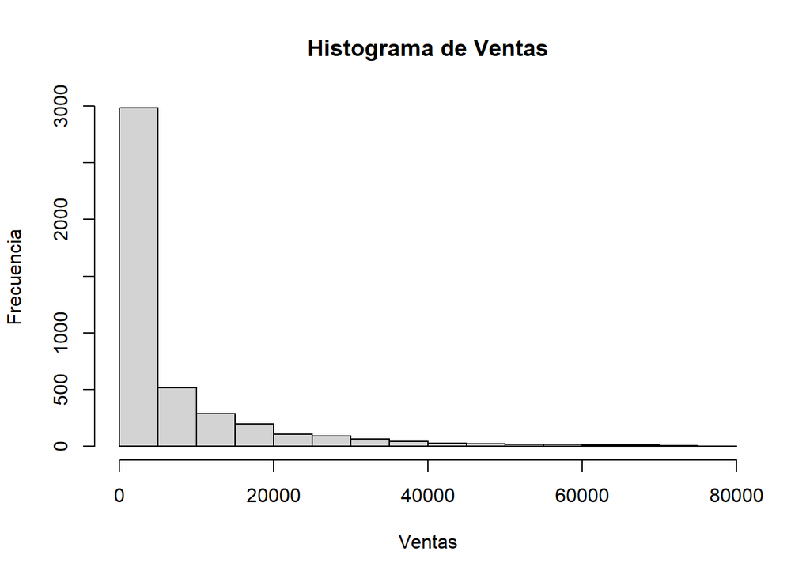

```r
hist(practica$VENTAS, main = "Histograma de Ventas", xlab = "Ventas", ylab = "Frecuencia" )
```

Se observa como las tiendas con mayores volúmenes de ventas están más dispersas.

**Como ya vimos, las variables no siguen una distribución normal; para seguir con el análisis considero que es preciso normalizar alguna de ellas, mediante logaritmos (no aplicar a valores negativos ni dicotómicas), y así suaviazar sus distribuciones:**

```r
practica_log <- practica |>
  mutate(
    VENTAS = log(VENTAS),
    liq = log(liq),
    conce = log(conce),
    coe = log(coe),
    numest = log(numest),
    NºEmp = log(NºEmp),
  )
practica_log
```

```
## # A tibble: 4,403 x 15
##    rentabieco rentabifin  endp      liq Pdtvidad VENTAS NºEmp   coe  edad conce
##         <dbl>      <dbl> <dbl>    <dbl>    <dbl>  <dbl> <dbl> <dbl> <dbl> <dbl>
##  1      0.860       8.40  89.8  0.0968    115.     7.15 0     -5.31     2  2.20
##  2     -4.75      -20.1   76.4  0.269     146.     5.82 0     -6.64     8  2.20
##  3     -0.322      -1.93  83.3 -0.158      11.7    9.78 3.83  -2.68    25  3.53
##  4     13.0        28.4   54.2  0.456      19.3    9.95 3.69  -2.51    24  3.53
##  5      1.46       55.7   97.4  0.00922    37.0    7.12 0.693 -5.34     2  1.10
##  6      1.59        6.80  76.5  0.232      13.1    9.91 3.99  -2.55    40  3.53
##  7      9.97       31.7   68.5 -0.531      12.0    5.61 0     -6.85    10  3.53
##  8      4.38       11.3   61.3 -0.0582     70.8    7.56 0.693 -4.90    11  3.53
##  9      1.75       10.2   82.9  0.0585      4.94   5.95 2.08  -6.51    10  2.20
## 10      0.225      -1.57 114.   0.233       2.50   5.52 0.693 -6.94    15  3.53
## # ... with 4,393 more rows, and 5 more variables: numac <dbl>, numpa <dbl>,
## #   numest <dbl>, estp <fct>, GRUPOS_PROVINCIAS <fct>
```

Procedo a comprobar nuevamente la normalidad de mis datos:

```r
normalidad <- sapply((dplyr::select(practica_log, -GRUPOS_PROVINCIAS, -estp)), shapiro.test)
normalidad
```

```
##           rentabieco                    rentabifin
## statistic 0.6228056                     0.6703634
## p.value   2.798948e-71                  1.423589e-68
## method    "Shapiro-Wilk normality test" "Shapiro-Wilk normality test"
## data.name "X[[i]]"                      "X[[i]]"
##           endp                          liq
## statistic 0.8169595                     0.8637137
## p.value   2.179416e-57                  3.641315e-52
## method    "Shapiro-Wilk normality test" "Shapiro-Wilk normality test"
## data.name "X[[i]]"                      "X[[i]]"
##           Pdtvidad                      VENTAS
## statistic 0.5893254                     0.9871587
## p.value   5.147669e-73                  1.359813e-19
## method    "Shapiro-Wilk normality test" "Shapiro-Wilk normality test"
## data.name "X[[i]]"                      "X[[i]]"
##           NºEmp                         coe
## statistic 0.959367                      0.9925617
## p.value   2.006367e-33                  2.134443e-14
## method    "Shapiro-Wilk normality test" "Shapiro-Wilk normality test"
## data.name "X[[i]]"                      "X[[i]]"
##           edad                          conce
## statistic 0.9273678                     0.9693397
## p.value   7.027458e-42                  1.107083e-29
## method    "Shapiro-Wilk normality test" "Shapiro-Wilk normality test"
## data.name "X[[i]]"                      "X[[i]]"
##           numac                         numpa
## statistic 0.7215549                     0.2374069
## p.value   2.929726e-65                  2.736419e-86
## method    "Shapiro-Wilk normality test" "Shapiro-Wilk normality test"
## data.name "X[[i]]"                      "X[[i]]"
##           numest
## statistic 0.7242865
## p.value   4.547552e-65
## method    "Shapiro-Wilk normality test"
## data.name "X[[i]]"
```

Siguen sin ser normales, pero se aproximan más a una distribución normal.

##### Una vez vistas las variables de forma individual, vamos a analizar las correlaciones más significativas de las variables numéricas:

Aplicamos la correlación de Spearman ya que queremos medir la relación entre variables y no se cumple el supuesto de normalidad.

```r
corr <-
dplyr::select(practica_log, -estp, -GRUPOS_PROVINCIAS)
```

```r
correlacion_indep <-round (cor(corr, method = "spearman"), 2)
correlacion_indep
```

```
##            rentabieco rentabifin  endp   liq Pdtvidad VENTAS NºEmp   coe  edad
## rentabieco       1.00       0.36 -0.50  0.37     0.16   0.24  0.17  0.22  0.14
## rentabifin       0.36       1.00  0.17 -0.08     0.16  -0.05 -0.14 -0.04 -0.26
## endp            -0.50       0.17  1.00 -0.66     0.04  -0.28 -0.33 -0.27 -0.42
## liq              0.37      -0.08 -0.66  1.00     0.02   0.14  0.12  0.11  0.22
## Pdtvidad         0.16       0.16  0.04  0.02     1.00   0.49  0.00  0.42 -0.10
## VENTAS           0.24      -0.05 -0.28  0.14     0.49   1.00  0.81  0.84  0.41
## NºEmp            0.17      -0.14 -0.33  0.12     0.00   0.81  1.00  0.70  0.53
## coe              0.22      -0.04 -0.27  0.11     0.42   0.84  0.70  1.00  0.37
## edad             0.14      -0.26 -0.42  0.22    -0.10   0.41  0.53  0.37  1.00
## conce           -0.03      -0.04 -0.02  0.00     0.19   0.26  0.16  0.12  0.05
## numac            0.16      -0.06 -0.25  0.12     0.18   0.54  0.49  0.48  0.33
## numpa            0.06      -0.07 -0.16  0.05     0.05   0.33  0.34  0.28  0.26
## numest           0.09      -0.03 -0.11  0.02     0.11   0.43  0.43  0.35  0.23
##            conce numac numpa numest
## rentabieco -0.03  0.16  0.06   0.09
## rentabifin -0.04 -0.06 -0.07  -0.03
## endp       -0.02 -0.25 -0.16  -0.11
## liq         0.00  0.12  0.05   0.02
## Pdtvidad    0.19  0.18  0.05   0.11
## VENTAS      0.26  0.54  0.33   0.43
## NºEmp       0.16  0.49  0.34   0.43
## coe         0.12  0.48  0.28   0.35
## edad        0.05  0.33  0.26   0.23
## conce       1.00  0.14  0.10   0.11
## numac       0.14  1.00  0.26   0.27
## numpa       0.10  0.26  1.00   0.22
## numest      0.11  0.27  0.22   1.00
```

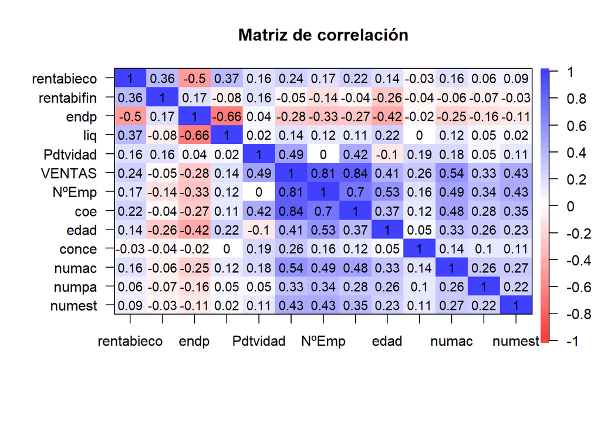

```r
corPlot(correlacion_indep, cex = 0.90, main = "Matriz de correlación")
```

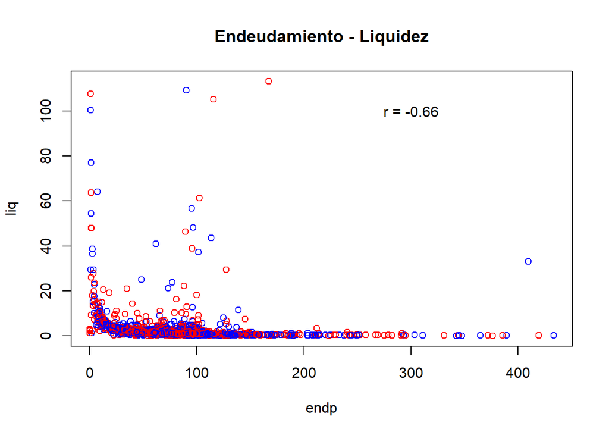

```r
cor_coef3 = cor(practica$endp, practica$liq, method = "spearman")
plot(x = practica$endp, y = practica$liq, main = "Endeudamiento - Liquidez", xlab = "endp", ylab = "liq", pch = 1, col = c("blue", "red"))
text(300, 100, glue::glue ("r = {round (cor_coef3, 2)}"))
```

- Se observa correlación negativa del -0.5 entre Endp y rentabieco. En caso de tener que prescindir de una de ellas para el modelo de regresión, debería elegirse la que a su vez esté más correlacionada con la variable de ventas.

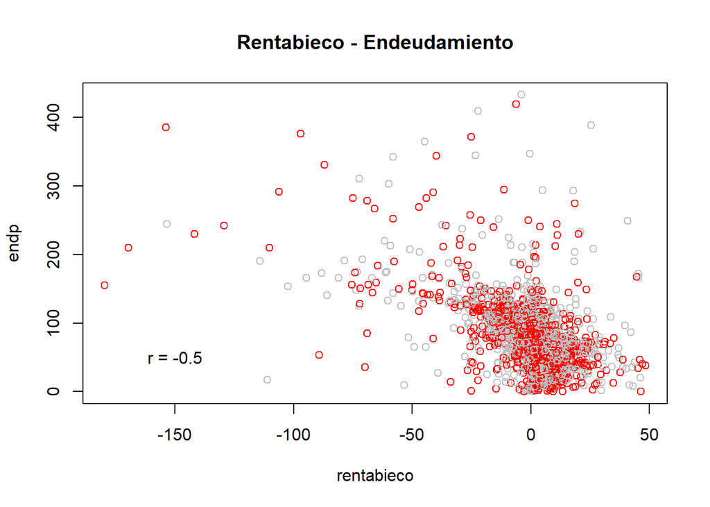

```r
cor_coef4 =cor(practica$rentabieco, practica$endp, method = "spearman")
plot(x = practica$rentabieco, y = practica$endp, main = "Rentabieco - Endeudamiento", xlab = "rentabieco", ylab = "endp", pch = 1, col = c("grey", "red"))
text(-150, 50, glue::glue ("r = {round (cor_coef4, 2)}"))
```

- Correlación positiva del 0.49 entre Ventas y Productividad. Se traduce en que el área de ventas es eficiente. (Lo vemos en el punto 2).
- Se observa correlación negativa de -0.42 entre la edad y el endeudamiento de las tiendas. Es comprensible, que a mayor antiguedad de la franquicia, menor sea su endeudamiento.

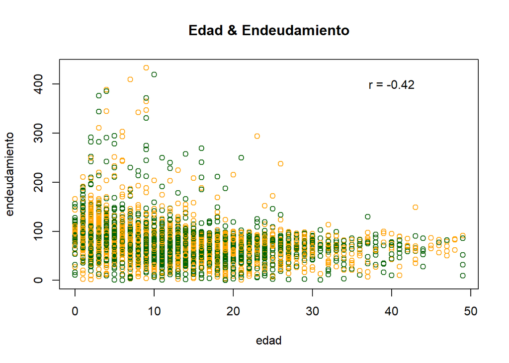

```r
cor_coef5 = cor(practica$edad, practica$endp, method = "spearman")
plot(x = practica$edad, y = practica$endp, main = "Edad & Endeudamiento", xlab = "edad", ylab = "endeudamiento", pch = 1, col = c("orange", "darkgreen"))
text(40, 400, glue::glue ("r = {round (cor_coef5, 2)}"))
```

- El coe correlaciona de manera positiva y significativa con ventas (0.84) y NºEmp (0.7). A su vez, presenta correlación positiva de 0.42 entre la cuota de mercado (coe) y la Productividad, como ya indicamos.

  También presenta correlación positiva significativa de 0.48 la cuota de mercado (coe) y el nº de accionistas (numac).

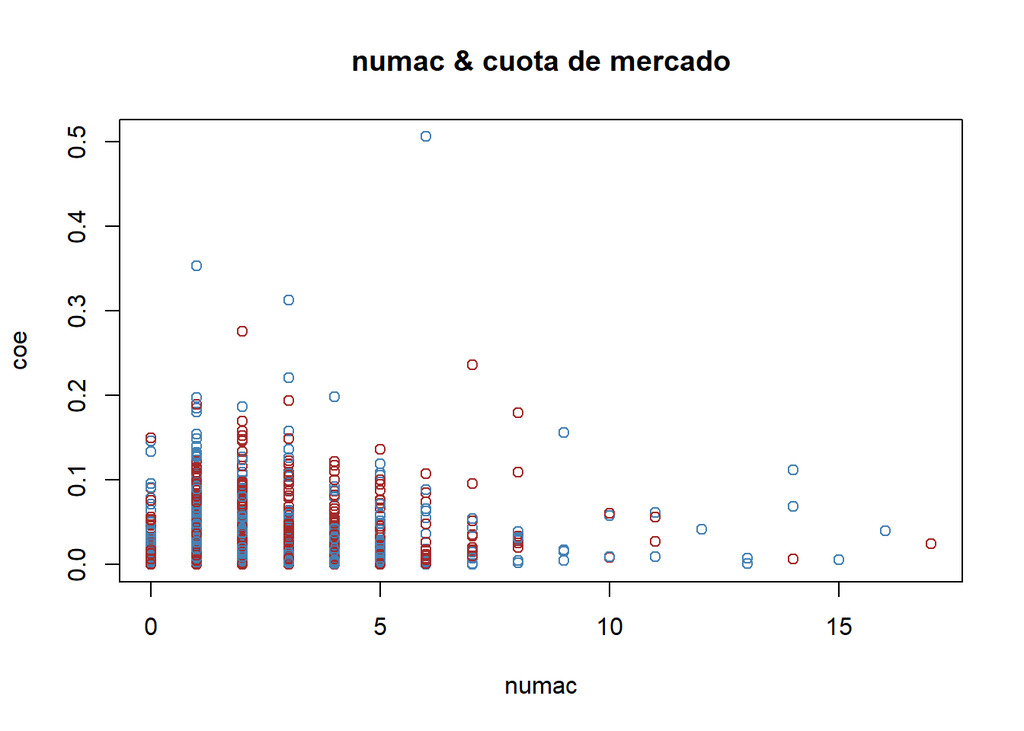

```
+ VENTAS : Lo veremos en profundidaz en el apartado 2.
```

```r
cor_coef6 = cor(practica$numac, practica$coe, method = "spearman")
plot(x = practica$numac, y = practica$coe, main = "numac & cuota de mercado", xlab = "numac", ylab = "coe", pch = 1, col = c("brown", "steelblue"))
text(100000, -100, glue::glue ("r = {round (cor_coef6, 2)}"))
```

##### **2. Análisis del Comportamiento de las Ventas y Variables que le Afectan.**

Lo primero que haremos será estudiar las correlaciones entre las variables numéricas; según vimos en el primer apartado, al aplicar sobre nuestros datos numéricos el test de Shapiro no seguían una distribución normal, por lo que aplicaremos la correlación de Spearman:

*— Ventas y rentabieco:*

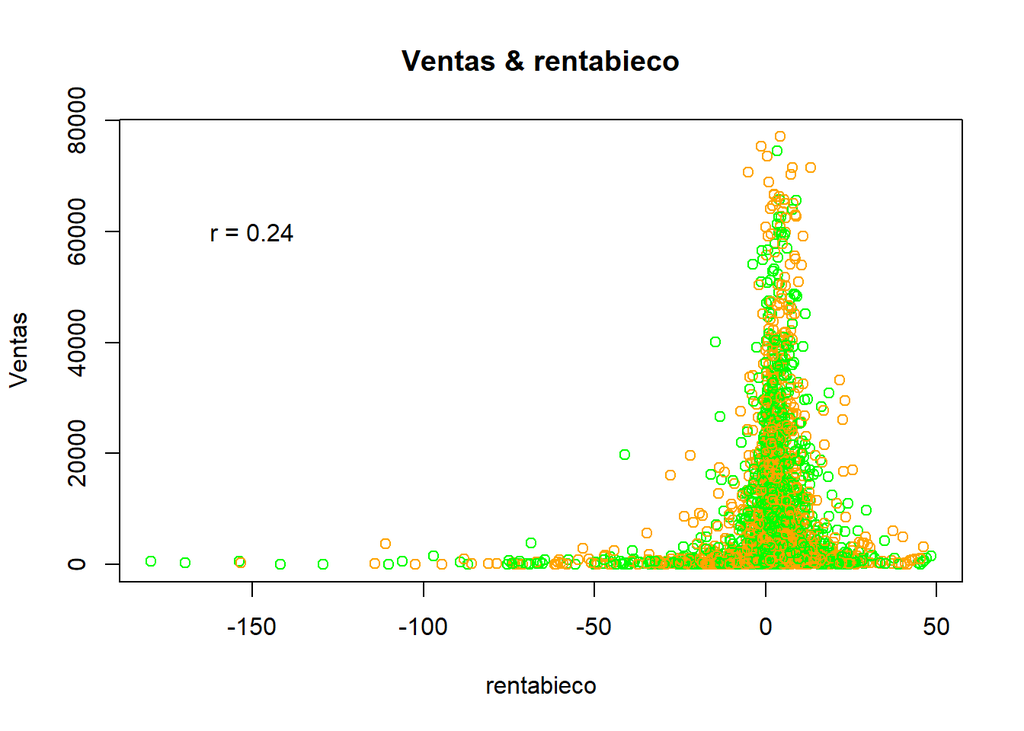

```r
cor_coef7 = cor(practica$rentabieco,practica$VENTAS, method = "spearman")
plot(x = practica$rentabieco, y = practica$VENTAS, main = "Ventas & rentabieco", xlab = "rentabieco", ylab = "Ventas", pch = 1, col = c("orange", "green"))
text(-150, 60000, glue::glue ("r = {round (cor_coef7, 2)}"))
```

Se observa una correlación positiva y débil entre ambas variables.

*— Ventas y rentabifin:*

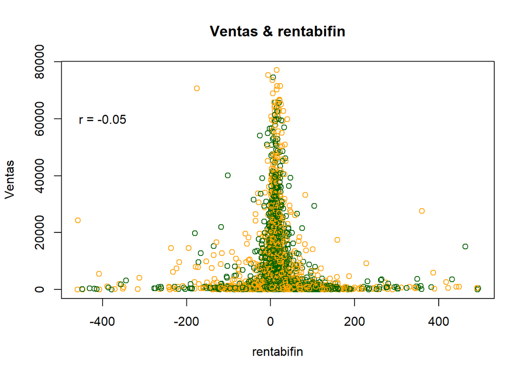

```r
cor_coef8 = cor(practica$rentabifin,practica$VENTAS, method = "spearman")
plot(x = practica$rentabifin, y = practica$VENTAS, main = "Ventas & rentabifin", xlab = "rentabifin", ylab = "Ventas", pch = 1, col = c("orange", "darkgreen"))
text(-400, 60000, glue::glue ("r = {round (cor_coef8, 2)}"))
```

Hay una correlación negativa muy débil y significativa entre ventas y rentabilidad financiera.

Ya habíamos observado que existía correlación entre rentabilidad económica y financiera en el apartado 1, y puesto que la correlación entre ventas y rentabilidades alcanza mayor valor para ventas y rentabieco, podremos prescindir de la rentabifin para nuestro modelo de predicción.

*— Ventas y endp:*

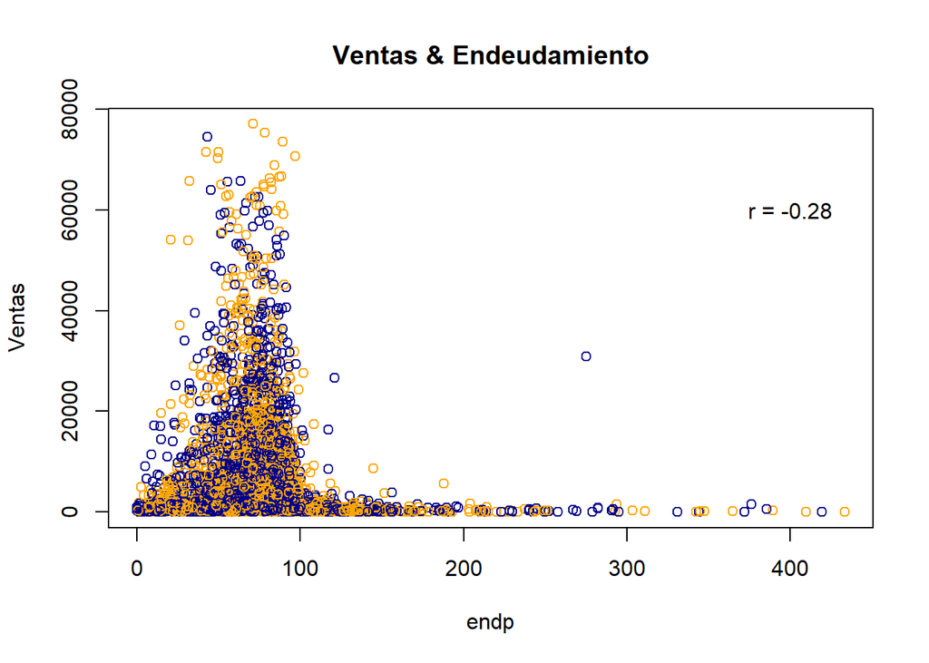

```r
cor_coef9 = cor(practica$endp, practica$VENTAS, method = "spearman")
plot(x = practica$endp, y = practica$VENTAS, main = "Ventas & Endeudamiento", xlab = "endp", ylab = "Ventas", pch = 1, col = c("orange", "darkblue"))
text(400, 60000, glue::glue ("r = {round (cor_coef9, 2)}"))
```

Correlación negativa y significativa entre ventas y endeudamiento de las tiendas.

*— Ventas y liq:*

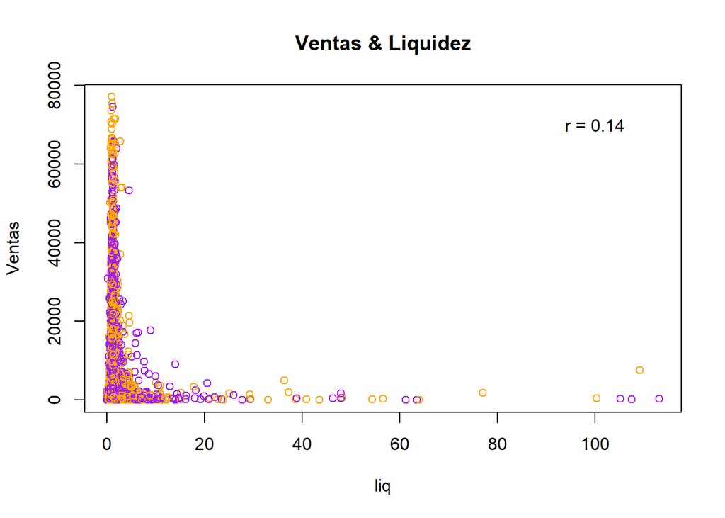

```r
cor_coef11 = cor(practica$liq,practica$VENTAS, method = "spearman")
plot(x = practica$liq, y = practica$VENTAS, main = "Ventas & Liquidez", xlab = "liq", ylab = "Ventas", pch = 1, col = c("orange", "purple"))
text(100, 70000, glue::glue ("r = {round (cor_coef11, 2)}"))
```

Hay una correlación positiva significativa, entre ventas y liquidez. Atendiendo a lo ya explicado, y dado que el endeudamiento está más correlacionado con las ventas que la liquidez, parece adecuado prescindir de la liquidez.

*— Ventas y Pdtividad:*

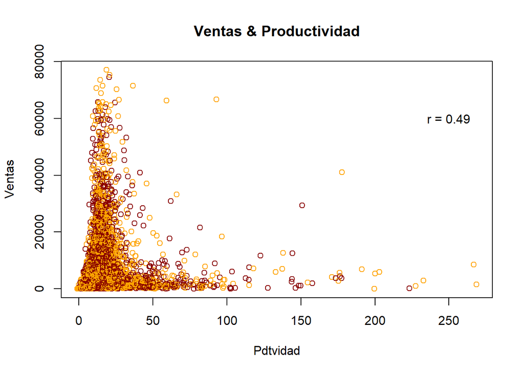

```r
cor_coef10 = cor(practica$Pdtvidad,practica$VENTAS, method = "spearman")
plot(x = practica$Pdtvidad, y = practica$VENTAS, main = "Ventas & Productividad", xlab = "Pdtvidad", ylab = "Ventas", pch = 1, col = c("orange", "darkred"))
text(250, 60000, glue::glue ("r = {round (cor_coef10, 2)}"))
```

Hay una correlación positiva y significativa entre las ventas y la productividad. Considero la productividad como variable relevante para mi modelo de predicción.

*— Ventas y NºEmpleados:*

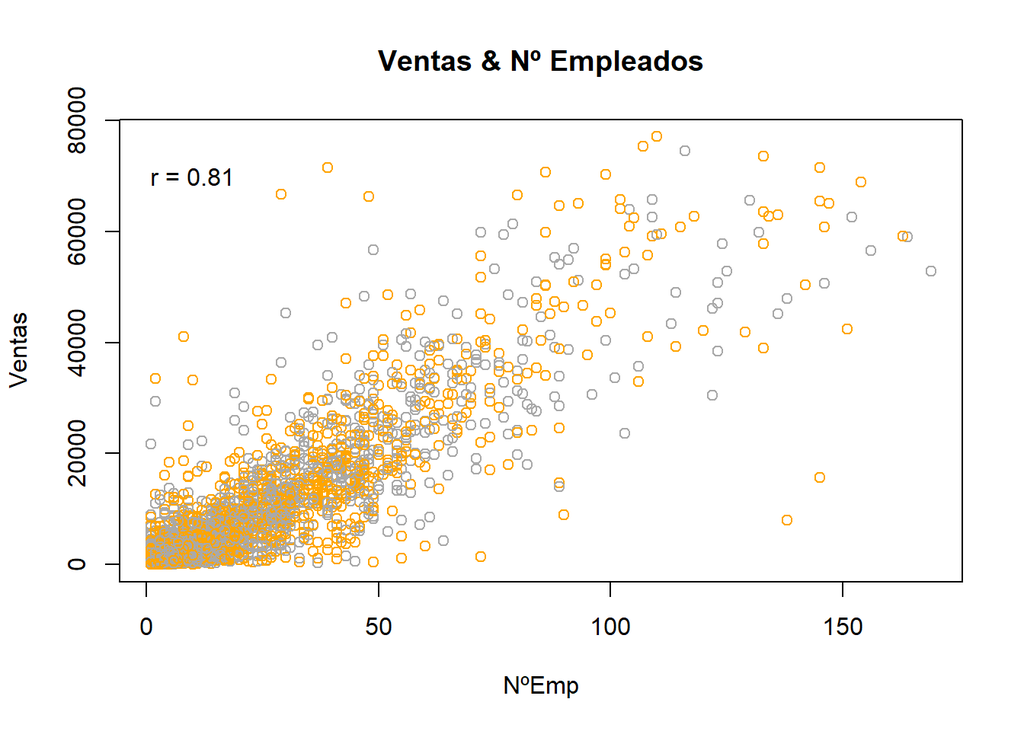

```r
cor_coef12 = cor(practica$NºEmp,practica$VENTAS, method = "spearman")
plot(x = practica$NºEmp, y = practica$VENTAS, main = "Ventas & Nº Empleados", xlab = "NºEmp", ylab = "Ventas", pch = 1, col = c("orange", "darkgrey"))
text(10, 70000, glue::glue ("r = {round (cor_coef12, 2)}"))
```

Existe correlación positiva y significativa entre ventas y Nº de empleados; considero que puede ser una variable significativa a la hora de confeccionar mi modelo de predicción.

*— Ventas y coe:*

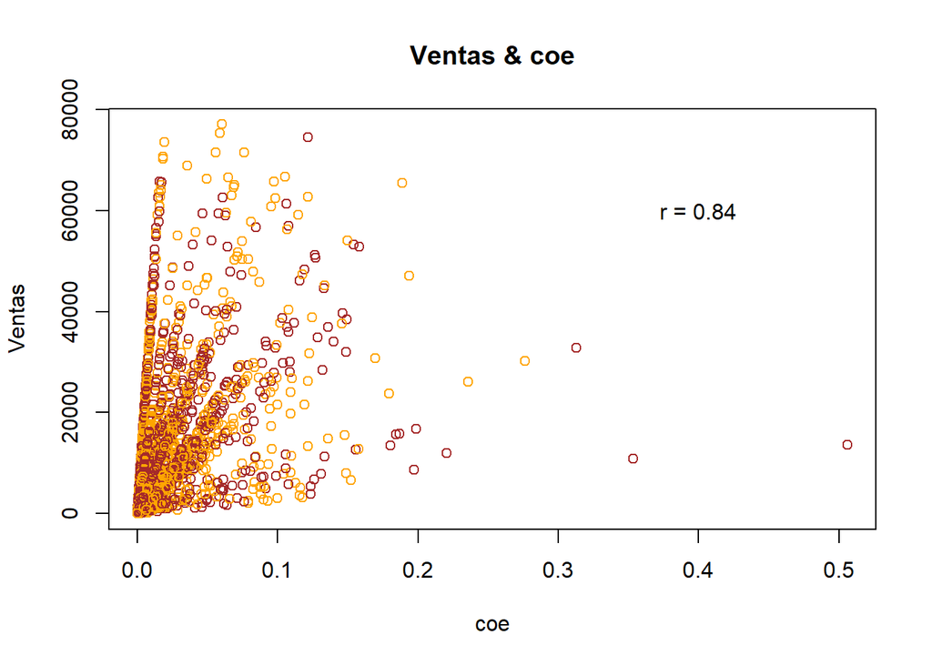

```r
cor_coef13 = cor(practica$coe,practica$VENTAS, method = "spearman")
plot(x = practica$coe, y = practica$VENTAS, main = "Ventas & coe", xlab = "coe", ylab = "Ventas", pch = 1, col = c("orange", "brown"))
text(0.4, 60000, glue::glue ("r = {round (cor_coef13, 2)}"))
```

Con una correlación positiva del 0.84 entre ventas y cuota de mercado, esta variable se tendría que tener en cuenta en el modelo de predicción; Es significativa y permite la determinación espacial. Lleva implícita las ventas, y habrá que ver si teníendola en cuenta puede distorsionar el modelo.

*— Ventas y edad:*

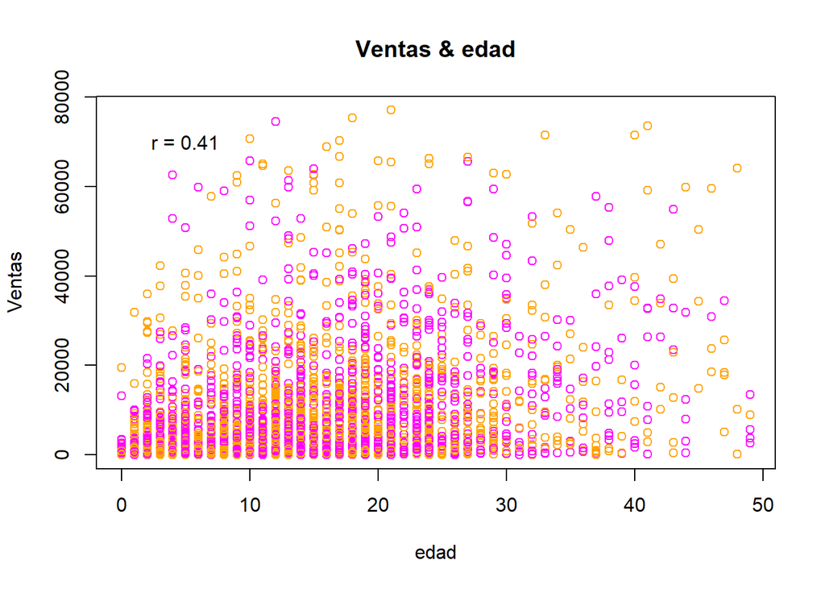

```r
cor_coef14 = cor(practica$edad,practica$VENTAS, method = "spearman")
plot(x = practica$edad, y = practica$VENTAS, main = "Ventas & edad", xlab = "edad", ylab = "Ventas", pch = 1, col = c("orange", "magenta"))
text(5, 70000, glue::glue ("r = {round (cor_coef14, 2)}"))
```

Hay correlación postiva y significativa entre ventas y antiguedad de las tiendas. Veremos qué ocurre al introducir esta variable en el modelo de regresión.